# Machine Learning For Econometrics

Linear model (with prior)

# Goals of this session

At the end of this session the student should be able to:

1. Estimate parameters of linear models using ordinary least squares, maximum likelihood, and stochastic gradient descent.
2. Perform regularized least squares.
3. Perform Bayesian linear regression (regression with prior) and discuss why bayesian regression is a case of regularized least squares.

# Introduction

The third week of the tutorial covers linear models for regression (Chapter 3 of Bishop’s book). This part starts the series of sessions which focuse on machine learning techniques and how these techniques can be implemented in R. Note that the codes here are merely for illustrative purposes. Hence, they are not optimized in any way.

# The Linear Model

Linear models for regression involve linear combination of the input variables

$$y(\mathbf{x},\mathbf{w})=w_0+w_1x_1+\dots+w_Dx_D$$
This is linear because the model is a linear function of the parameters $w_0,\dots,w_D$

The model can be extended by considering linear combinations of fixed nonlinear functions of the input variables.

$$y(\mathbf{x},\mathbf{w})=w_0+\sum_{j=1}^{M-1} w_j\phi_j(\mathbf{x})$$
where $\phi_j(\mathbf{x})$ are known as *basis functions*. Popular choices for the basis functions are

- Polynomial (specify parameter $j$; special case is $j=1$ which reduces to the simple linear model)

$$\phi_j(\mathbf{x})=x^j$$

- Gaussian (parameters: $\mu_j$ and $s$)

$$\phi_j(\mathbf{x})=\exp{\left\{-\frac{(x-\mu_j)^2}{2s^2}\right\}}$$

- Sigmoidal (parameters: $\mu_j$ and $s$)

$$\phi_j(\mathbf{x})=\sigma\left(\frac{x-\mu_j}{s}\right)$$
and many others (e.g. ‘tanh’, ‘splines’, ‘wavelets’, ‘Fourier’, etc.)

# Estimating parameters of the linear model

Next we will learn how to estimate the parameters using ordinary least, maximum likelihood, and stochastic gradient descent. To start this discussion and to get a better understanding of the estimation procedures, we will first look at an artificial example.

To be precise we will use the function:

$$\begin{aligned}
t_i & = f(x_i,\mathbf{w}) = w_0 + w_1 x_i + \epsilon_i \\
\epsilon_i & \sim N(\mu,\sigma)
\end{aligned}$$

With the parameters set to a $w_0 = -0.3$, $w_1 = 0.5$ and an error term which has a Gaussian distribution with mean $\mu=0$ and standard deviation $\sigma=0.2$ (this function is from the book).

Next we will simulate $N$ samples:

1. Choose $N$
2. Generate $N$ draws of $x$ from the uniform distribution with parameters -1 and +1
3. Generate $N$ draws of the error term $\epsilon$ from the gaussian distribution as specified above
4. Compute $t_i$ according to the specification above

In R you can write a function to generate $N$ samples:

```r
myFunc <- function(n){
  x <- runif(n, min=-1, max=1)
  error <- rnorm(n, mean=0, sd=0.2)
  target <- (-0.3+0.5*x)+error
  df <- data.frame(target,x)
  return(df)
}
```

To use just type:

```r
myValues <- myFunc(5) # generates the data
```

Our task here is using the generated data to see how we can estimate the parameters $w_0, w_1, \sigma$.

## Ordinary Least Squares

Let us first use ordinary least squares.

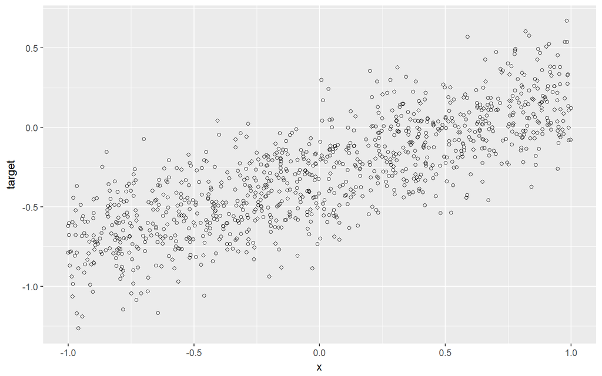

```r
set.seed(12345678)
myValues <- myFunc(1000)
ggplot(myValues, aes(x=x, y=target)) + geom_point(shape=1)
```

Recall that in ordinary least squares we are minimizing the squared loss function

$$E_D(\mathbf{w})=\frac{1}{2}\sum_{n=1}^{N}(t_n-y(\mathbf{x}_n,\mathbf{w}))^2$$
Using unconstrained optimization we get the $\mathbf{w}_{OL}$ which minimizes the function above and it is given by

$$w_{OL}=(X^TX)^{-1}X^Tt$$
Where $X$ is the matrix of input values (one column per input variable and the entries of the first column are all 1). Note here that $X$ is replaced by an appropriate basis function $\mathbf{\Phi}$ (see Bishop page 142)

```r
olsSolution <- function(mydata){
mydata <- cbind(intercept=rep(1, nrow(mydata)), mydata)
train_data <-unname(as.matrix(mydata[,-2]))
w_ols=(solve(t(train_data) %*% train_data) %*% t(train_data)) %*% mydata[[2]]
predic_values = (w_ols[2,1] * myValues[[2]]) + w_ols[1,1]
resid_values =  (predic_values-myValues[[1]])
return(list=c(w_0=w_ols[1,1], w_1=w_ols[2,1], sd_res=sd(resid_values)))
}

lm_ols<- olsSolution(myValues)
print(lm_ols)
```

```
##        w_0        w_1     sd_res
## -0.2940682  0.4837456  0.2006799
```

Compare the results with the `lm` function in R.

```r
rSolution<- function(mydata){
reg_model<-lm(target~x, data=mydata)
return(list=c(w_0=unname(coefficients(reg_model)[1]), w_1=unname(coefficients(reg_model)[2]), sd_res=sd(residuals(reg_model))))
}

lm_r=rSolution(myValues)
print(lm_r)
```

```
##        w_0        w_1     sd_res
## -0.2940682  0.4837456  0.2006799
```

## Maximum Likelihood Approach

Now let us use maximum likelihood approach. The predictive distribution is given by
$$p(t|\mathbf{x},\mathbf{w},\beta)=\mathcal{N}(t|y(\mathbf{x},\mathbf{w}),\beta^{-1})$$
therefore the likelihood function is

$$\ln p(\mathbf{t}|\mathbf{w},\beta)=\frac{N}{2}\ln{\beta}-\frac{N}{2}\ln{2\pi}-\beta E_D(\mathbf{w})$$
We need to maximize the likelihood with respect to the parameters. Let us code this in `R`.

```r
likelifunc <- function(estima,mydata){

  n=nrow(mydata)
  w_0 = estima[1]
  w_1 = estima[2]
  beta_est = estima[3]
  coef=c(w_0,w_1)
  x=unname(as.matrix(mydata[,-2]))
  target=mydata$target

  res <- target- (x %*% coef)
  logl <- n * 0.5 * log(beta_est) - n*0.5*log(2*pi)- beta_est* (sum(res^2)  )*.5
  return(-logl)

}

mlSolution <- function(mydata){
  mydata <- cbind(intercept=rep(1, nrow(mydata)), mydata)

  p<- optim(c(1,1,1), likelifunc, method="BFGS", hessian=T, mydata=mydata)
  return(list=c(w_0=p$par[1], w_1=p$par[2], sd_res=sqrt(1/p$par[3])))


}

lm_ml = mlSolution(myValues)
print(lm_ml)
```

```
##        w_0        w_1     sd_res
## -0.2940681  0.4837457  0.2005794
```

## Stochastic Gradient Descent

We now turn our attention to stochastic gradient descent (SGD) which is a popular sequential learning algorithm. The advantage of SGD over the previous methods is that it can process data points one at a time. Hence, it is suited for data observations arriving in a continuous stream because it updates the parameters in iterative fashion. Also for large data sets, SGD may save computational resources since it does not need to process the entire training set in one go.

SGD updates the parameter using

$$w^{(\tau + 1)}=w^{(\tau)}-\eta \nabla E_n$$
where $\eta$ is the learning rate and $\tau$ is the iteration number. The $\nabla E$ is the gradient of the error function which we can compute for each parameter in our case as

$$\nabla E = \frac{\partial E}{\partial \mathbf{w}}=
\begin{bmatrix}
\frac{\partial E}{\partial w_0} \\
\frac{\partial E}{\partial w_1}
\end{bmatrix}$$
where

$$\frac{\partial E}{\partial w_0}= - (t-(w_0 + w_1 x) )$$
and

$$\frac{\partial E}{\partial w_1}= -x \cdot (t-(w_0 + w_1 x))$$

We can interpret this in the following way: The gradient of the error function at a specific observation with respect to the intercept is proportional to the error and the gradient of the error function at a specific observation with respect to the slope is proportional to the product of the error and the value of the observation.

Note that an important parameter that we need to specify is the learning rate. Learning rate impacts the convergence of SGD to the solution.

```r
sgdSolution <- function(estima, mydata, learning_rate){
  new_w0= estima[1]
  new_w1 =estima[2]

  grad_w0= function(obsx, predx){
    return(-(obsx-predx))
  }

  grad_w1 = function(obsx,predx,inputx){
    return(-(inputx)*(obsx-predx))
  }

  for(obs in 1:nrow(mydata)){
    pred_val = sum(c(new_w0,new_w1) * c(1, mydata$x[obs]))
    new_w0 = new_w0 - learning_rate * grad_w0(mydata$target[obs], pred_val)
    new_w1 = new_w1 - learning_rate * grad_w1(mydata$target[obs], pred_val, inputx=mydata$x[obs])
  }

  return(list=c(w_0=new_w0, w_1=new_w1))

}
lm_sgd= sgdSolution(estima=c(1,1), mydata=myValues,learning_rate=0.01)
print(lm_sgd)
```

```
##        w_0        w_1
## -0.2987946  0.4914016
```

# Regularized Least Squares

From the lecture the error function for regularized regression is

$$E_D(\mathbf{w}) + \lambda E_W (\mathbf{w})$$
where $E_D(\mathbf{w})$ is the same as before and $E_W(\mathbf{w})=\frac{1}{2}\mathbf{w}^{\mathsf{T}}\mathbf{w}$ is the regularizer. Minimizing this will result to

$$\mathbf{w}_{RLS}=(\lambda \mathbf{I} + \Phi^{\mathsf{T}}\Phi)^{-1} \Phi^{\mathsf{T}}\mathbf{t}$$
In R

```r
olsregSolution <- function(mydata, lambda){
  mydata= cbind(intercept=rep(1, nrow(mydata)), mydata)
  train_data <-unname(as.matrix(mydata[,-2]))
  w_ols_reg=(solve(lambda * diag(2) + t(train_data) %*% train_data) %*% t(train_data)) %*% mydata[[2]]
  return(list(w_0=w_ols_reg[1,1], w_1=w_ols_reg[2,1]))
}


lmregular <- olsregSolution(mydata=myValues, lambda=0.1)
print(lmregular)
```

```
## $w_0
## [1] -0.2940366
##
## $w_1
## [1] 0.4835929
```

# Bayesian Regression

In Bayesian Regression, we have to set a prior for the parameters we want to estimate. Here we are going to reproduce the results from Bishop (pages 152-156).

The prior for the coefficients is

$$p(\mathbf{w})=\mathcal{N} (\mathbf{w}|\mathbf{m}_0, \mathbf{S}_0)$$

and the posterior is

$$p(\mathbf{w}|\mathbf{t})=\mathcal{N} (\mathbf{w}|\mathbf{m}_N, \mathbf{S}_N)$$

where

$$\mathbf{m}_N = \mathbf{S}_N (\mathbf{S}_{0}^{-1}\mathbf{m}_0 + \beta \Phi^{\mathsf{T}}\mathbf{t})$$

$$\mathbf{S}_N^{-1}= \mathbf{S}_{0}^{-1} + \beta \Phi^{\mathsf{T}}\Phi$$
The maximum posterior weight is therefore given by

$$\mathbf{w}_{MAP}=\mathbf{m}_N$$

One good thing about bayesian regression is like stochastic gradient descent, data can be processed sequentially whereby the prior is updated in light of the evidence (i.e. data). The posterior at any stage acts as the prior for the subsequent data point. Let us code this in R.

We need to specify the initial prior distribution and some parameters. Here we assume that the initial prior is normal, with mean $\mathbf{m}_0 = [0,0]$ and covariance $S_0 = \alpha^{-1}\mathbf{I}$ where we set $\alpha = 2.0$. Same as in the book we wont estimate $\beta$ and we set it equal to 25.

```r
bayesSolution <- function(mydata,alpha, beta){
  mydata= unname(as.matrix(cbind(intercept=rep(1, nrow(mydata)), mydata) ))
  alphaI=alpha * diag(1, 2)
  for(obs in 2:nrow(mydata)){
    S= solve(alphaI + beta * t(mydata[1:obs,-2]) %*% mydata[1:obs,-2])
    m = as.vector(beta * S %*%  t(mydata[1:obs,-2]) %*% matrix(mydata[1:obs,2]))


  }
  return(list(w_0=m[1], w_1=m[2]))
}

lm_br <-bayesSolution(mydata=myValues, alpha=2.0, beta=25)
print(lm_br)
```

```
## $w_0
## [1] -0.2940429
##
## $w_1
## [1] 0.4836234
```

# Comparison

Now let us compare the performance of each method and see which one converges to the answer the fastest.

```r
compare_df_w0 <- data.frame(num_point=numeric(), ols=numeric(),ml=numeric(), sgd=numeric(),regular=numeric(),br=numeric())
compare_df_w1 <- data.frame(num_point=numeric(), ols=numeric(),ml=numeric(), sgd=numeric(),regular=numeric(),br=numeric())
for(k in seq(50, 1000, 50)){
  lm_ols<- olsSolution(myValues[1:k,])
  lm_ml = mlSolution(myValues[1:k,])
  lm_sgd= sgdSolution(estima=c(1,1), mydata=myValues[1:k,],learning_rate=0.01)
  lmregular <- olsregSolution(mydata=myValues[1:k,], lambda=0.1)
  lm_br <-bayesSolution(mydata=myValues[1:k,], alpha=2.0, beta=25)

  compare_df_w0 <- rbind(compare_df_w0,data.frame(num_point=k,ols=lm_ols[1], ml=lm_ml[1],sgd=lm_sgd[1],regular=lmregular$w_0,br=lm_br$w_0), make.row.names=FALSE)

  compare_df_w1 <- rbind(compare_df_w1,data.frame(num_point=k,ols=lm_ols[2], ml=lm_ml[2],sgd=lm_sgd[2],regular=lmregular$w_1,br=lm_br$w_1), make.row.names=FALSE)

}

head(compare_df_w1)
```

```
##   num_point       ols        ml       sgd   regular        br
## 1        50 0.5210301 0.5210302 0.8843587 0.5179031 0.5185256
## 2       100 0.5446371 0.5446354 0.8436582 0.5429897 0.5433184
## 3       150 0.5511503 0.5511491 0.8148107 0.5499335 0.5501765
## 4       200 0.5449094 0.5449101 0.7779557 0.5439830 0.5441681
## 5       250 0.5353934 0.5353952 0.7498240 0.5346587 0.5348055
## 6       300 0.5269988 0.5269955 0.7098013 0.5264317 0.5265450
```

```r
head(compare_df_w0)
```

```
##   num_point        ols         ml         sgd    regular         br
## 1        50 -0.2681182 -0.2681182  0.48679443 -0.2673538 -0.2675062
## 2       100 -0.2851716 -0.2851697  0.17770353 -0.2848452 -0.2849104
## 3       150 -0.2904843 -0.2904842 -0.01077019 -0.2902777 -0.2903190
## 4       200 -0.3074674 -0.3074682 -0.14756096 -0.3073062 -0.3073384
## 5       250 -0.3038801 -0.3038800 -0.19344257 -0.3037706 -0.3037925
## 6       300 -0.3012877 -0.3012842 -0.22298492 -0.3012048 -0.3012214
```

> Which among the methods is the slowest in terms of convergence to the solution?

Vladimer Kobayashi

2017-11-14